# Strike Zone Estimation

Kay.YOSHI

2021/10/27

## Data Acquisition

```r
# Call packages
library(mlbr)
library(stringr)

# Statcast pitch-by-pitch data on all regular season games in 2019 (731,784 obs.)
mlb2019 = sc_pbp(start_date = "2019-03-28", end_date = "2019-09-29")

# Remove missing values for plate_x, plate_z, sz_bot, and sz_top
mlb =
  mlb2019 %>%
  subset(!(is.na(plate_x))) %>%
  subset(!(is.na(plate_z))) %>%
  subset(!(is.na(sz_bot))) %>%
  subset(!(is.na(sz_top)))
```

## Pitch distribution conditional on not swinging

```r
# Random seed
set.seed(1)

# Preparation & Random sampling
dist =
  mlb %>%
  filter(pitch_type == "FF") %>%
  filter(description == "called_strike" | description == "ball" | description == "blocked_ball" | description == "pitchout") %>%
  mutate(code = ifelse(description == "called_strike", "Called Strike", "Ball")) %>%
  mutate(code2 = as.factor(ifelse(description == "called_strike", 1, -1))) %>%
  sample_n(10000)

# Rulebook strike zone
# ※Upper and lower bound of strike zone are average across hitters.
plate_width = (17 + 2 * (9 / pi)) / 12 # Home plate: 17 inches, ball: 9 inches (1 inch = 1/12 feet)
xm = c(-(plate_width / 2), plate_width / 2, plate_width / 2, -(plate_width / 2), -(plate_width / 2))
zm = c(mean(dist$sz_bot), mean(dist$sz_bot), mean(dist$sz_top), mean(dist$sz_top), mean(dist$sz_bot))
sz_mlb = tibble(xm, zm)

# Visualization
pdist =
  ggplot(dist, aes(x = plate_x, y = plate_z)) +
  geom_point(aes(color = code), alpha = 1.0) +
  geom_path(data = sz_mlb, aes(x = xm, y = zm), linejoin = "round", size = 1.0) +
  coord_equal() +
  scale_x_continuous("Horizontal location (ft.)", limits = c(-2.0, 2.0)) +
  scale_y_continuous("Vertical location (ft.)", limits = c(0.0, 5.0)) +
  scale_color_manual(values = c("green", "red")) +
  labs(title = "Pitch distribution",
       subtitle = "(Randomly sampled 10,000 obs.)", caption = "*Catcher's perspective.") +
  theme_bw() +
  theme(title = element_text(size = 8)) +
  theme(axis.title.x = element_text(size = 8, colour = "black")) +
  theme(axis.title.y = element_text(size = 8, colour = "black")) +
  theme(axis.text.x = element_text(size = 5, colour = "black")) +
  theme(axis.text.y = element_text(size = 5, colour = "black")) +
  theme(legend.title=element_blank()) +
  theme(legend.position = "bottom") +
  theme(legend.text=element_text(size = 8))
```

## Estimating strike zone by local polynomial regression

```r
# Call libraries
library(mgcv)
library(splancs)

# Fit a smooth polynomial surface
# CAUTION: It takes too much time to estimate using whole observations.
strike_mod = loess(code == "Called Strike" ~ plate_x + plate_z, data = dist, control = loess.control(surface = "direct"))

# Construct a grid
mx = seq(-2.0, 2.0, by = 0.01)
my = seq(0, 5, by = 0.01)
pred_area = expand.grid(plate_x = mx, plate_z = my)

# Called strike probability predictions across the entire grid
pred_area_fit_lpr =
  pred_area %>%
  mutate(fit_lpr = as.numeric(predict(strike_mod, newdata = .)))

# Visualization
pred_area_fit_lpr2 = pred_area_fit_lpr %>% filter(0 <= fit_lpr & fit_lpr <= 1) # For logical consistency
Szone_lpr =
  # Contour plot
  ggplot(pred_area_fit_lpr2, aes(x = plate_x, y = plate_z)) +
  stat_contour(aes(z = fit_lpr), color = "black", size = 1.0, breaks = 0.5) +
  scale_color_gradient(low = "black", high = "black") +
  # Strike zone
  geom_path(data = sz_mlb, aes(x = xm, y = zm), linejoin = "round", linetype = "dashed") +
  coord_equal() +
  scale_x_continuous("Horizontal location (ft.)", limits = c(-2.0, 2.0)) +
  scale_y_continuous("Vertical location (ft.)", limits = c(0.0, 5.0)) +
  labs(title = "Estimated strike zone", subtitle = "(By local polynomial regression)",
       caption = "*Catcher's perspective.") +
  theme_bw() +
  theme(title = element_text(size = 8)) +
  theme(axis.title.x = element_text(size = 8, colour = "black")) +
  theme(axis.title.y = element_text(size = 8, colour = "black")) +
  theme(axis.text.x = element_text(size = 5, colour = "black")) +
  theme(axis.text.y = element_text(size = 5, colour = "black")) +
  theme(legend.position = "none")

# Compute the contour areas

# Obtain x and y coordinates of 50% contour line
clines.lpr = contourLines(x = mx, y = my, array(pred_area_fit_lpr$fit_lpr, dim = c(length(mx), length(my))), nlevels = 1, levels = 0.5)

# Compute the area (sq. in.) inside 50% contour line
area50.lpr = round(with(clines.lpr[[1]], areapl(cbind(12 * x, 12 * y))), 3)
```

## Estimating strike zone by Support Vector Machine (SVM)

```r
# Call libraries
library(kernlab)

# Fitting SVM
ksvmfit = ksvm(code2 ~ plate_x + plate_z, data = dist, kernel = "rbfdot", type = "C-svc", C = 1, cross = 10)

# Predictions across the entire grid
fit_svm = as.numeric(predict(ksvmfit, pred_area)) - 1
pred_area_fit_svm = cbind(pred_area, fit_svm)

# Plot decision boundary
Szone_svm =
  ggplot(pred_area_fit_svm, aes(x = plate_x, y = plate_z)) +
  stat_contour(aes(z = fit_svm), color = "black", size = 1.0, breaks = 0.5) +
  geom_path(data = sz_mlb, aes(x = xm, y = zm), linejoin = "round", linetype = "dashed") +
  coord_equal() +
  scale_x_continuous("Horizontal location (ft.)", limits = c(-2.0, 2.0)) +
  scale_y_continuous("Vertical location (ft.)", limits = c(0.0, 5.0)) +
  labs(title = "Estimated strike zone", subtitle = "(By SVM)",
       caption = "*Catcher's perspective.") +
  theme_bw() +
  theme(title = element_text(size = 8)) +
  theme(axis.title.x = element_text(size = 8, colour = "black")) +
  theme(axis.title.y = element_text(size = 8, colour = "black")) +
  theme(axis.text.x = element_text(size = 5, colour = "black")) +
  theme(axis.text.y = element_text(size = 5, colour = "black")) +
  theme(legend.title=element_blank()) +
  theme(legend.position = "bottom") +
  theme(legend.text=element_text(size = 8))

# Compute the contour areas
# Obtain x and y coordinates of 50% contour line
clines.svm = contourLines(x = mx, y = my, array(pred_area_fit_svm$fit_svm, dim = c(length(mx), length(my))), nlevels = 1, levels = 0.5)

# Compute the area (sq. in.) inside 50% contour line
area50.svm = round(with(clines.svm[[1]], areapl(cbind(12 * x, 12 * y))), 3)
```

## Estimated strike zone

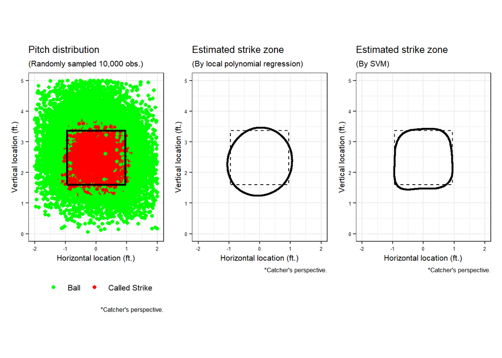

```r
# Call libraries
library(patchwork)

# Visualization
pdist + Szone_lpr + Szone_svm
```

```r
# Size of the estimated strike zone by local polynomial regression
area50.lpr
```

```
## [1] 531.198
```

```r
# Size of the estimated strike zone by SVM
area50.svm
```

```
## [1] 483.098
```

The estimated strike zone from local polynomial regression is about 10% greater than that from Support Vector Machine: the former has an area of 531 square inches and the latter has an area of 483 square inches.

[NOTE] The decision boundary from SVM depends only on observations close to the boundary (support vectors). On the other hand, the boundary from regressions depends on all observations and is easily affected by anomalies. Although local regression mitigates this problem, the estimated boundary would be unstable in some cases, for example, in regions with few observations.

## Estimating strike zone by B-S count

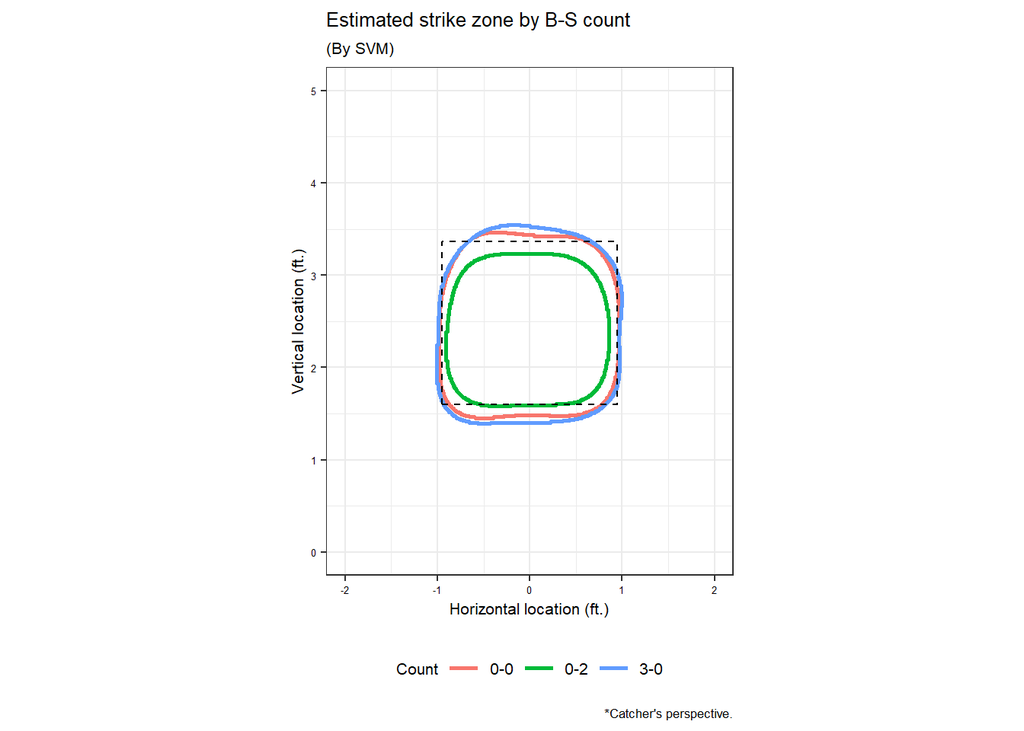

```r
# Preparation
dat =
  mlb %>%
  filter(pitch_type == "FF") %>%
  filter(description == "called_strike" | description == "ball" | description == "blocked_ball" | description == "pitchout") %>%
  mutate(code = as.factor(ifelse(description == "called_strike", 1, -1))) %>%
  mutate(count = paste(balls, strikes, sep = "-"))

# Observation when B-S count is 0-0
count00 = dat %>% filter(count == "0-0") %>% sample_n(10000)
count02 = dat %>% filter(count == "0-2")
count30 = dat %>% filter(count == "3-0")

# Height of the rulebook strike zone (averaged across counts)
sz_bots = c(count00$sz_bot, count02$sz_bot, count30$sz_bot)
sz_tops = c(count00$sz_top, count02$sz_top, count30$sz_top)
zm2 = c(mean(sz_bots), mean(sz_bots), mean(sz_tops), mean(sz_tops), mean(sz_bots))
sz_mlb2 = tibble(xm, zm2)

# Fitting SVM
ksvmfit00 = ksvm(code ~ plate_x + plate_z, data = count00, kernel = "rbfdot", type = "C-svc", C = 1, cross = 10)
ksvmfit02 = ksvm(code ~ plate_x + plate_z, data = count02, kernel = "rbfdot", type = "C-svc", C = 1, cross = 10)
ksvmfit30 = ksvm(code ~ plate_x + plate_z, data = count30, kernel = "rbfdot", type = "C-svc", C = 1, cross = 10)

# Predictions across the entire grid
fit00 = as.numeric(predict(ksvmfit00, pred_area)) - 1
fit02 = as.numeric(predict(ksvmfit02, pred_area)) - 1
fit30 = as.numeric(predict(ksvmfit30, pred_area)) - 1
predictions = cbind(pred_area, fit00, fit02, fit30)
predictions2 = predictions %>% gather(count, value, -plate_x, -plate_z)

# Compute the contour areas

# Obtain x and y coordinates of 50% contour line
clines00 = contourLines(x = mx, y = my, array(predictions$fit00, dim = c(length(mx), length(my))), nlevels = 1, levels = 0.5)
clines02 = contourLines(x = mx, y = my, array(predictions$fit02, dim = c(length(mx), length(my))), nlevels = 1, levels = 0.5)
clines30 = contourLines(x = mx, y = my, array(predictions$fit30, dim = c(length(mx), length(my))), nlevels = 1, levels = 0.5)

# Compute the area (sq. in.) inside 50% contour line
area00 = round(with(clines00[[1]], areapl(cbind(12 * x, 12 * y))), 3)
area02 = round(with(clines02[[1]], areapl(cbind(12 * x, 12 * y))), 3)
area30 = round(with(clines30[[1]], areapl(cbind(12 * x, 12 * y))), 3)

# Plot decision boundaries
ggplot(predictions2) +
  stat_contour(aes(x = plate_x, y = plate_z, z = value, colour = count), size = 1.0, breaks = 0.5) +
  geom_path(data = sz_mlb2, aes(x = xm, y = zm2), linejoin = "round", linetype = "dashed") +
  coord_equal() +
  scale_x_continuous("Horizontal location (ft.)", limits = c(-2.0, 2.0)) +
  scale_y_continuous("Vertical location (ft.)", limits = c(0.0, 5.0)) +
  labs(title = "Estimated strike zone by B-S count", subtitle = "(By SVM)",
       caption = "*Catcher's perspective.") +
  theme_bw() +
  theme(title = element_text(size = 8)) +
  theme(axis.title.x = element_text(size = 8, colour = "black")) +
  theme(axis.title.y = element_text(size = 8, colour = "black")) +
  theme(axis.text.x = element_text(size = 5, colour = "black")) +
  theme(axis.text.y = element_text(size = 5, colour = "black")) +
  theme(legend.position = "bottom") +
  theme(legend.text=element_text(size = 8)) +
  scale_color_discrete(name = "Count", labels = c("0-0", "0-2", "3-0"))
```

```r
# Size of the estimated strike zone in 3-0 counts
area30
```

```
## [1] 544.5
```

```r
# Size of the estimated strike zone in 0-0 counts
area00
```

```
## [1] 505.865
```

```r
# Size of the estimated strike zone in 0-2 counts
area02
```

```
## [1] 371.239
```

Compared with the strike zone in count 0-0, it expands in 3-0 counts and shrinks in 0-2 counts. The size of the strike zone in 3-0 counts is about 47% greater than that in 0-2 counts.

## References

Marchi, M., Albert, J. and Baumer, B. S.: “Analyzing Baseball Data with R (2nd ed.),” Chapman and Hall/CRC (2018)

James, G., Witten, D., Hastie, T. and Tibshirani, R.: “An Introduction to Statistical Learning with Applications in R,” Springer Science+Business Media, New York (2013)

Green, E. and Daniels, D.: “Bayesian Instinct,” Available at SSRN: https://ssrn.com/abstract=2916929 (2021)

Mills, B.: “Expert Workers, Performance Standards, and On-the-Job Training: Evaluating Major League Baseball Umpires,” Available at SSRN: https://ssrn.com/abstract=2478447 (2014)